# BIM254 Hw1

Eric Kalosa-Kenyon

20 February 2018

Abstract

In this assignment, I examine SHAPE-seq data for a Staph plasmid.

# Introduction

SHAPE reactivity experiments probe the structure of nucleic acid products, usually RNA. To do so, a binding agent (in this case SHAPE) is introduced into a solution containing the target RNA molecule. Ideally, SHAPE binds with higher affinity to more exposed, non-paired portions of the molecule (e.g. hairpin loops) and with less affinity to paired portions of the molecule (e.g. helices). The following analysis esposes some of the raw data produced by such a SHAPE reactivity experiment, examines coverage, and calculates differential reactivity using two methods.

# Reactivity

## Aviran et al. 2011

$$\beta_k^{(A)} = \frac{
\frac{x_k}{\sum_{i=k}^{n+1}{x_i}} - \frac{y_k}{\sum_{i=k}^{n+1}{y_i}}
}{
1 - \frac{y_k}{\sum_{i=k}^{n+1}{y_i}}
} \vee 0$$

## Using both methods to calculate reactivity

The following table is a brief snippet of the raw stop count data, presented in full at the end of this report in the appendix.

| five_prime_offset | nucleotide | treated_mods | untreated_mods |
| --- | --- | --- | --- |
| 1 | G | 1675 | 5250 |
| 2 | G | 609 | 1915 |
| 3 | C | 112 | 476 |
| 4 | C | 1235 | 3502 |
| 5 | T | 3264 | 7212 |
| 6 | T | 312 | 638 |
| 7 | C | 286 | 223 |
| 8 | G | 220 | 379 |
| 9 | G | 562 | 1907 |

The following plot shows the reactivity of the pT181 plasmid as calculated using the formula presented in Aviran et al. 2011 and Ding et al. 2014.

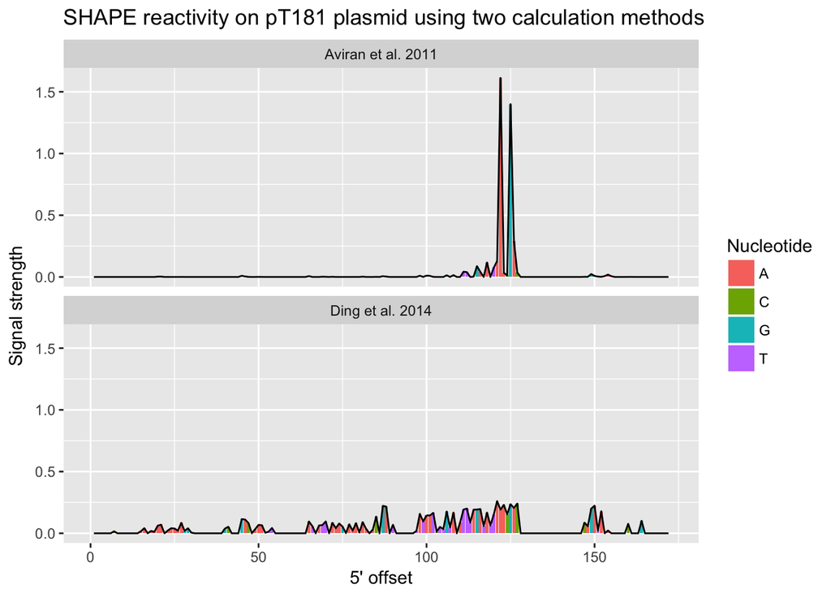

Note that the Aviran et al. 2011 plot above reproduces Figure 3.b in ibid.

# Non-uniformity of coverage in the SHAPE reactivity data

The plot below shows the non-uniform nucleotide-level coverage between treated and untreated samples in the (+) channel.

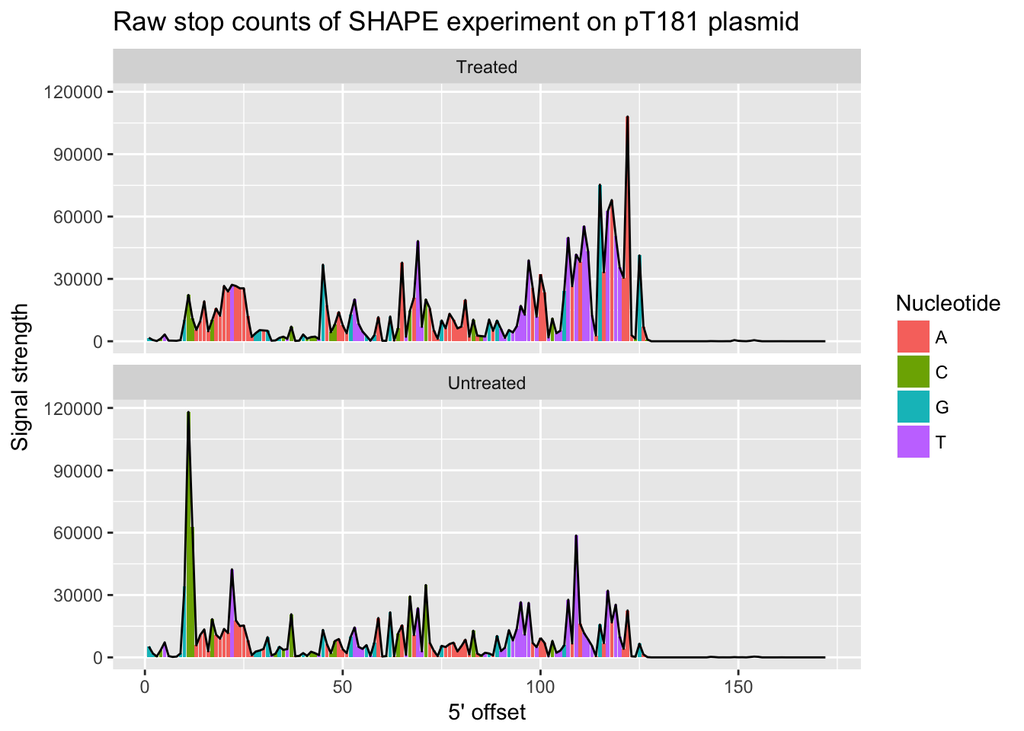

# Sources

1. Sharon Aviran, Julius B. Lucks, and Lior Pachter; “RNA structure characterization from chemical mapping experiments”; Forty-ninth Annual Allerton Conference Allerton House, UIUC, Illinois, USA September 2011
2. Yiliang Ding, Yin Tang, Chun Kit Kwok, Yu Zhang, Philip C. Bevilacqua, and Sarah M. Assmann; “In vivo genome-wide profiling of RNA secondary structure reveals novel regulatory features”; Nature 2014; doi:10.1038/nature12756

# Appendix

## Source code

```
# Author: Eric Kalosa-Kenyon

## @knitr setup

rm(list=ls())

library(ggplot2)
library(reshape)

d = read.table("./pT181_Sense_112_adducts.txt", header=T)

## @knitr reactivity

x = c(d$treated_mods[-1],
      d$treated_mods[1])
y = c(d$untreated_mods[-1],
      d$untreated_mods[1])
n = length(x) - 1
stopifnot(length(x) == length(y))

ba = function(k) {
    # Reactivity calculation from Aviran et al. 2011
    stopifnot(k>=0)

    a = x[k] / sum(x[-(1:k)])
    b = y[k] / sum(y[-(1:k)])
    numer = a-b
    denom = 1-b
    r = numer/denom
    if(is.nan(r)){return(0)}
    return(max(r,0))
}

bd = function(k) {
    # Reactivity calculation from Ding et al. 2014
    stopifnot(k>=0)

    na = log(1+x[k])
    da = (1/n)*sum(log(1+x))
    nb = log(1+y[k])
```

[output cut: 26 more lines]

```
## @knitr plot_coverage

dp = melt(d[-1,], id=c("nucleotide", "five_prime_offset"))
levels(dp$variable) = c("Treated", "Untreated")
co = colnames(dp)
co[1] = "Nucleotide"
colnames(dp) = co

p2 = ggplot(dp, aes(x=five_prime_offset, y=value)) +
    geom_histogram(aes(fill=Nucleotide), stat="identity") +
    geom_freqpoly(stat="identity") +
    facet_wrap(~variable, nrow=2) +
    labs(
        title="Raw stop counts of SHAPE experiment on pT181 plasmid",
        x="5' offset", y="Signal strength")
```

## Data

pT181 Sense 112 adducts

| five_prime_offset | nucleotide | treated_mods | untreated_mods |
| --- | --- | --- | --- |
| 0 | * | 20392 | 63919 |
| 1 | G | 1675 | 5250 |
| 2 | G | 609 | 1915 |
| 3 | C | 112 | 476 |
| 4 | C | 1235 | 3502 |
| 5 | T | 3264 | 7212 |
| 6 | T | 312 | 638 |
| 7 | C | 286 | 223 |
| 8 | G | 220 | 379 |
| 9 | G | 562 | 1907 |
| 10 | G | 10192 | 34015 |
| 11 | C | 22245 | 118071 |
| 12 | C | 11077 | 62720 |
| 13 | A | 5467 | 5819 |
| 14 | A | 9714 | 10823 |
| 15 | A | 19217 | 13438 |
| 16 | A | 4822 | 2966 |
| 17 | C | 10132 | 18389 |
| 18 | A | 15718 | 10921 |
| 19 | A | 12291 | 9012 |
| 20 | A | 26612 | 13679 |
| 21 | A | 23924 | 11719 |
| 22 | T | 27156 | 42351 |
| 23 | A | 26582 | 17781 |
| 24 | A | 25458 | 15078 |
| 25 | A | 25470 | 15331 |
| 26 | A | 12027 | 8289 |
| 27 | A | 2094 | 986 |
| 28 | G | 3894 | 2798 |
| 29 | G | 5353 | 3296 |

[output cut: 143 more lines]